# Basic R Tutorial

# Introduction to R Programming

## What is R?

R is a programming language for statistical computing and data visualization. It has been adopted in the fields of data mining, bioinformatics, and data analysis. The core R language is augmented by a large number of extension packages, containing reusable code, documentation, and sample data.

## Installing R and RStudio

1. Download R from [CRAN](https://cran.r-project.org/)
2. Download RStudio from [RStudio](https://rstudio.com/products/rstudio/download/)
3. Install R first, then RStudio

## RStudio Interface

RStudio consists of: - **Console**: Where you can type and execute R commands. - **Source Editor**: Where you can write and save scripts. - **Environment/History**: Where you can view and manage your workspace. - **Plots/Packages/Help/Viewer**: Various tools for visualization, package management, and help documentation.

## Basic Syntax and Data Types

### Basic Syntax

```r
print('Hello world!')
```

```r
# This is a comment
x <- 10  # Assigning a value to a variable
print(x)  # Print the value of x

# Simple math operations
a <- 5 + 2
b <- a * 3
c <- b / a
d <- c - 1
print(d)
```

### Data Types

> **Definition**: A numeric data type can store both integer and floating-point numbers but is stored as a double-precision floating-point by default in R.

#### Integer

Integer data types represent whole numbers.

```r
# Integer type (with L suffix)
int <- 42L
int
```

```
## [1] 42
```

```r
typeof(int)
```

```
## [1] "integer"
```

> **Definition**: An integer data type is explicitly created by appending an ‘L’ to the number. It stores whole numbers without any decimal component.

#### Complex

Complex data types represent complex numbers with real and imaginary parts.

```r
# Complex type
comp <- 2 + 3i
comp
```

```
## [1] 2+3i
```

```r
typeof(comp)
```

```
## [1] "complex"
```

> **Definition**: A complex data type can store numbers with both a real and an imaginary component.

#### Character

Character data types represent text strings.

```r
# Character type
char <- "Hello, R!"
char
```

```
## [1] "Hello, R!"
```

```r
typeof(char)
```

```
## [1] "character"
```

> **Definition**: A character data type stores sequences of characters or strings.

#### Logical

Logical data types represent boolean values.

```r
# Logical type
logi <- TRUE
logi
```

```
## [1] TRUE
```

```r
typeof(logi)
```

```
## [1] "logical"
```

> **Definition**: A logical data type stores boolean values: `TRUE` or `FALSE`.

#### Raw

Raw data types represent raw bytes.

```r
# Raw type
raw_data <- charToRaw("Hello")
raw_data
```

```
## [1] 48 65 6c 6c 6f
```

```r
typeof(raw_data)
```

```
## [1] "raw"
```

> **Definition**: A raw data type stores bytes and is used for binary data manipulation.

#### Vectors

Vectors are sequences of data elements of the same basic type.

```r
# Numeric vector
num_vec <- c(1.5, 2.5, 3.5)
num_vec
```

```
## [1] 1.5 2.5 3.5
```

```r
typeof(num_vec)
```

```
## [1] "double"
```

```r
# Integer vector
int_vec <- c(1L, 2L, 3L)
int_vec
```

```
## [1] 1 2 3
```

```r
typeof(int_vec)
```

```
## [1] "integer"
```

```r
# Character vector
char_vec <- c("a", "b", "c")
char_vec
```

```
## [1] "a" "b" "c"
```

```r
typeof(char_vec)
```

```
## [1] "character"
```

```r
# Logical vector
logi_vec <- c(TRUE, FALSE, TRUE)
logi_vec
```

```
## [1]  TRUE FALSE  TRUE
```

```r
typeof(logi_vec)
```

```
## [1] "logical"
```

> **Definition**: A vector is a basic data structure in R that holds elements of the same type (numeric, integer, character, or logical).

#### Lists

Lists are sequences of elements that can be of different types.

```r
# List type
lst <- list(1, "a", TRUE)
lst
```

```
## [[1]]
## [1] 1
##
## [[2]]
## [1] "a"
##
## [[3]]
## [1] TRUE
```

```r
typeof(lst)
```

```
## [1] "list"
```

> **Definition**: A list is a data structure in R that can hold elements of different types (numbers, strings, vectors, etc.).

#### Factors

Factors are used to represent categorical data.

```r
# Factor type
fctr <- factor(c("low", "medium", "high"))
fctr
```

```
## [1] low    medium high
## Levels: high low medium
```

```r
typeof(fctr)
```

```
## [1] "integer"
```

> **Definition**: A factor is used for categorical data and stores both the values and their levels.

#### Data Frames

Data frames are used to store tabular data.

```r
# Data Frame type
df <- data.frame(numbers = c(1, 2, 3), letters = c("a", "b", "c"))
df
```

```
##   numbers letters
## 1       1       a
## 2       2       b
## 3       3       c
```

```r
typeof(df)
```

```
## [1] "list"
```

> **Definition**: A data frame is a table or 2-dimensional array-like structure in which each column contains values of one variable and each row contains a set of values from each column.

#### Matrices

Matrices are 2-dimensional arrays with elements of the same type.

```r
# Matrix type
mat <- matrix(1:9, nrow = 3)
mat
```

```
##      [,1] [,2] [,3]
## [1,]    1    4    7
## [2,]    2    5    8
## [3,]    3    6    9
```

```r
typeof(mat)
```

```
## [1] "integer"
```

> **Definition**: A matrix is a 2-dimensional array that holds elements of the same type, arranged in rows and columns.

#### Arrays

Arrays are multi-dimensional generalizations of matrices.

```r
# Array type
arr <- array(1:8, dim = c(2, 2, 2))
arr
```

```
## , , 1
##
##      [,1] [,2]
## [1,]    1    3
## [2,]    2    4
##
## , , 2
##
##      [,1] [,2]
## [1,]    5    7
## [2,]    6    8
```

```r
typeof(arr)
```

```
## [1] "integer"
```

> **Definition**: An array is a data structure that can store data in more than two dimensions.

#### Date and Time

Date and time types are used to store date and time information.

```r
# Date type
dt <- as.Date("2024-01-01")
dt
```

```
## [1] "2024-01-01"
```

```r
typeof(dt)
```

```
## [1] "double"
```

```r
# POSIXct type (Date-time)
dt_time <- as.POSIXct("2024-01-01 12:34:56")
dt_time
```

```
## [1] "2024-01-01 12:34:56 +07"
```

```r
typeof(dt_time)
```

```
## [1] "double"
```

This R Markdown document provides a brief definition and example for each data type in R. When you knit this document, it will display the values and types of different data structures used in R, along with their definitions.

## Variables and Data Structures

```r
a <- 5  # Creating a variable
b <- "Data Science"
c <- TRUE

print(a)
print(b)
print(c)
```

Variable names must start with a letter and can include letters, numbers, underscores, and periods.

## Vectors

```r
v <- c(1, 2, 3, 4)  # Creating a vector
print(v)

# Accessing elements
print(v[1])
print(v[2:4])

# Vector operations
v2 <- c(5, 6, 7, 8)
sum_v <- v + v2
print(sum_v)

product_v <- v * 2
print(product_v)
```

## Matrices

```r
# Creating a matrix
m <- matrix(1:9, nrow=3, ncol=3)
print(m)

# Accessing elements
print(m[1, 2])
print(m[, 1])
print(m[2, ])

# Matrix operations
m2 <- matrix(9:1, nrow=3, ncol=3)
sum_m <- m + m2
print(sum_m)

product_m <- m * 2
print(product_m)
```

## Lists

```r
# Creating a list
l <- list(name="John", age=25, scores=c(85, 90, 88))
print(l)

# Accessing elements
print(l$name)
print(l[[2]])
print(l$scores)
```

## Data Frames

```r
# Creating a data frame
df <- data.frame(name=c("John", "Jane"), age=c(25, 30), scores=c(85, 90))
print(df)

# Accessing elements
print(df$name)
print(df[1, ])
print(df[1, "age"])
print(df[df$age > 25, ])
```

## Basic Operations

### Arithmetic

```r
add <- 5 + 3
subtract <- 8 - 2
multiply <- 4 * 3
divide <- 16 / 4

print(add)
print(subtract)
print(multiply)
print(divide)
```

### Relational

```r
greater <- 5 > 3
less <- 3 < 5
equal <- 4 == 4
not_equal <- 7 != 6

print(greater)
print(less)
print(equal)
print(not_equal)
```

### Logical

```r
and <- TRUE & FALSE
or <- TRUE | FALSE
not <- !TRUE

print(and)
print(or)
print(not)
```

## Statement operation and Loop

```r
# If statement
num <- 3
if (num > 0) {
  print("The number is positive.")
} else if (num < 0) {
  print("The number is negative.")
} else {
  print("The number is zero.")
}

# For loop
for (i in 1:5) {
  print(i)
}

# While loop
sum <- 0
count <- 1
while (count <= 5) {
  sum <- sum + count
  count <- count + 1
}
print(sum)
```

## Functions and Packages

### Creating Functions

```r
# Defining a function
my_function <- function(x, y) {
  result <- x + y
  return(result)
}

# Using the function
output <- my_function(4, 5)
print(output)
```

### Installing and Loading Packages

```r
# Installing a package
install.packages("dplyr")

# Loading a package
library(dplyr)

# Using a function from the package
sample_data <- tibble(
  id = 1:5,
  score = c(90, 85, 88, 95, 92)
)
print(sample_data)
```

## Data Import and Export

### Reading Data

[Download Sample Data](https://raw.githubusercontent.com/aeiwz/R_tutorial/main/src/data/sample_data.csv)

```r
# Reading a CSV file
data <- read.csv("https://raw.githubusercontent.com/aeiwz/R_tutorial/main/src/data/sample_data.csv")
print(head(data))
```

## Visualize Data

```r
view(data)
```

## Add column to data

```r
data$Group <- c('A', 'B', 'A', 'B', 'A')
```

### Writing Data

```r
# Writing to a CSV file
write.csv(data, "output_data.csv")
```

## Data Manipulation

### Subsetting

```r
# Subsetting data
subset_data <- data[data$age > 25, ]
print(subset_data)
```

### Using dplyr

Cheat sheet (dplyr): https://www.rstudio.com/wp-content/uploads/2015/02/data-wrangling-cheatsheet.pdf

```r
library(dplyr)

# Filtering rows
filtered_data <- filter(data, age > 25)
print(filtered_data)

# Selecting columns
selected_data <- select(data, name, age)
print(selected_data)

# Adding new variables
mutated_data <- mutate(data, age_next_year = age + 1)
print(mutated_data)

# Summarizing data
summary_data <- summarise(data, mean_age = mean(age))
print(summary_data)
```

## Data Visualization

### Basic Plots

Cheat sheet (ggplot2): https://www.maths.usyd.edu.au/u/UG/SM/STAT3022/r/current/Misc/data-visualization-2.1.pdf

```r
# Creating a basic plot
x <- c(1, 2, 3, 4, 5)
y <- c(2, 3, 5, 7, 11)
plot(x, y, type="b", col="blue", main="Basic Plot", xlab="X-Axis", ylab="Y-Axis")
```

### Using ggplot2

```r
library(ggplot2)

# Creating a scatter plot
ggplot(data, aes(x=age, y=scores)) +
  geom_point() +
  ggtitle("Scatter Plot") +
  xlab("Age") +
  ylab("Scores")
```

## Basic Statistical Analysis

### Descriptive Statistics

```r
mean_age <- mean(data$age)
sd_age <- sd(data$age)
median_score <- median(data$scores)

print(mean_age)
print(sd_age)
print(median_score)
```

### Hypothesis Testing

```r
t_test_result <- t.test(data$age ~ data$group)
print(t_test_result)
```

### Correlation and Regression

```r
correlation <- cor(data$age, data$scores)
print(correlation)

# Linear regression
model <- lm(scores ~ age, data=data)
print(summary(model))

# Plotting the regression line
ggplot(data, aes(x=age, y=scores)) +
  geom_point() +
  geom_smooth(method="lm", col="red") +
  ggtitle("Linear Regression") +
  xlab("Age") +
  ylab("Scores")
```

# Data Visualization in R

## Load Libraries

```r
# Load necessary libraries
library(ggplot2)
library(datasets)  # Iris dataset is included in this package
library(stats)     # For PCA function
```

## Load Data

```r
# Load the Iris dataset
data(iris)
head(iris)
```

```
##   Sepal.Length Sepal.Width Petal.Length Petal.Width Species
## 1          5.1         3.5          1.4         0.2  setosa
## 2          4.9         3.0          1.4         0.2  setosa
## 3          4.7         3.2          1.3         0.2  setosa
## 4          4.6         3.1          1.5         0.2  setosa
## 5          5.0         3.6          1.4         0.2  setosa
## 6          5.4         3.9          1.7         0.4  setosa
```

## Perform PCA

```r
# Perform PCA on the numeric columns of the Iris dataset
pca_result <- prcomp(iris[, 1:4], center = TRUE, scale. = TRUE)

# Display PCA result summary
summary(pca_result)
```

```
## Importance of components:
##                           PC1    PC2     PC3     PC4
## Standard deviation     1.7084 0.9560 0.38309 0.14393
## Proportion of Variance 0.7296 0.2285 0.03669 0.00518
## Cumulative Proportion  0.7296 0.9581 0.99482 1.00000
```

## PCA Biplot

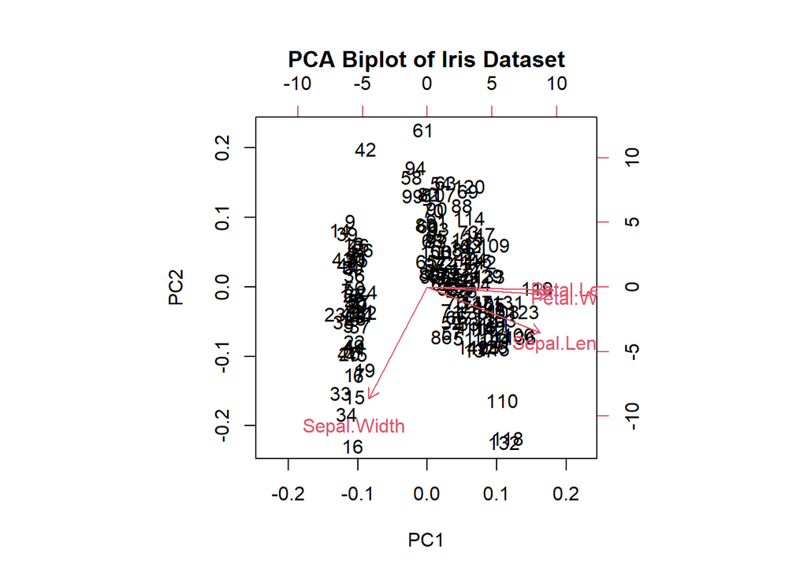

```r
# Biplot of PCA
biplot(pca_result, main = "PCA Biplot of Iris Dataset")
```

## Visualize PCA Results

### PCA Scores Plot

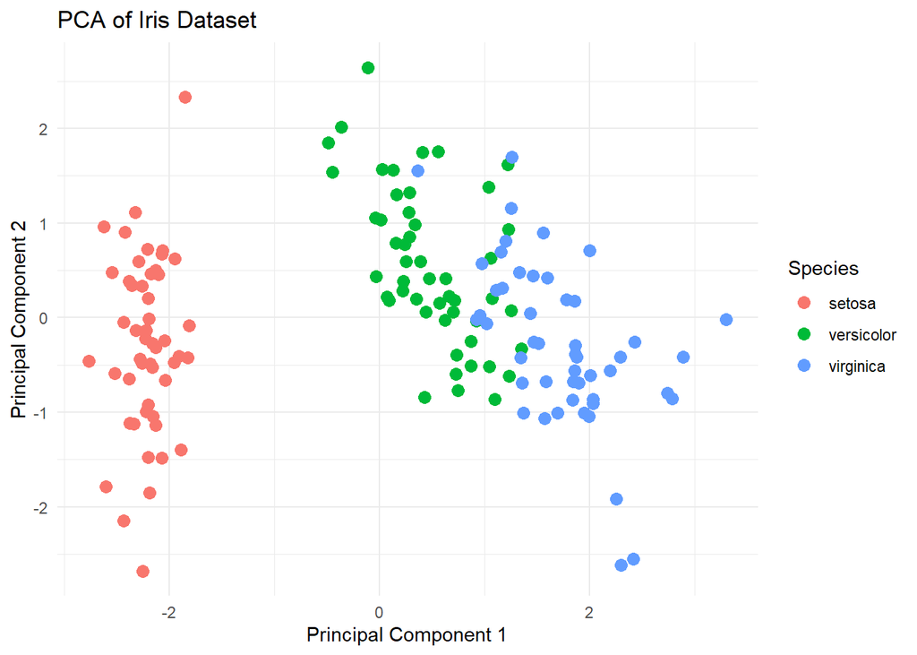

```r
# Create a data frame with PCA scores and species for visualization
pca_scores <- as.data.frame(pca_result$x)
pca_scores$Species <- iris$Species

# Plot the first two principal components
ggplot(pca_scores, aes(x = PC1, y = PC2, color = Species)) +
  geom_point(size = 3) +
  labs(title = "PCA of Iris Dataset",
       x = "Principal Component 1",
       y = "Principal Component 2") +
  theme_minimal()
```

### Explained Variance

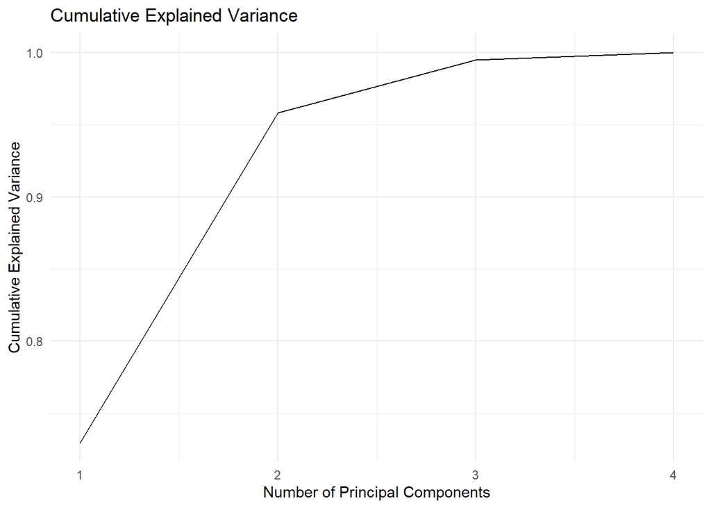

```r
# Plot the variance explained by each principal component
explained_variance <- summary(pca_result)$sdev^2
explained_variance <- explained_variance / sum(explained_variance)

# Plot the cumulative variance explained
qplot(x = 1:length(explained_variance), y = cumsum(explained_variance), geom = "line") +
  labs(title = "Cumulative Explained Variance",
       x = "Number of Principal Components",
       y = "Cumulative Explained Variance") +
  theme_minimal()
```

## Conclusion

This tutorial demonstrated how to perform PCA on the Iris dataset and visualize the results. PCA helps in reducing the dimensionality of the dataset while preserving as much variance as possible.

[output not shown]